# Table of Contents

**Kernel Author:**  
[Bhishan Poudel, Ph.D Astrophysics](https://bhishanpdl.github.io/) .

# Data Description

> The datasets contains transactions made by credit cards in September 2013 by european cardholders.

> This dataset presents transactions that occurred in two days, where we have 492 frauds out of 284,807 transactions.

> The dataset is highly unbalanced, the positive class (frauds) account for 0.172% of all transactions.

> It contains only numerical input variables which are the result of a PCA transformation.

> Unfortunately, due to confidentiality issues, we cannot provide the original features and more background information about the data.

> Features V1, V2, ... V28 are the principal components obtained with PCA, the only features which have not been transformed with PCA are 'Time' and 'Amount'.

> Feature 'Time' contains the seconds elapsed between each transaction and the first transaction in the dataset. The feature 'Amount' is the transaction Amount, this feature can be used for example-dependant cost-senstive learning.

> Feature 'Class' is the response variable and it takes value 1 in case of fraud and 0 otherwise.

# Business Problem

**Business Problem:**  
Task : Detect the fraudulent activities.  
Metric : Recall  
Sampling: Synthetic Minority Over-Sampling Technique (SMOTE)  
Question: How many frauds are correctly classified?

Remember that `Recall = TP / (TP + FN)`. In case of fraud detection, classifying a fraud as non-fraud (FN) is more risky so we use the metric `recall` to compare the performances of the models. Higher the recall, better is the model.

Also, we should note that the data is just of two days, we implicitly assume that these two days are represent of the whole trend and reflects the property of the population properly.

The could have been more or less fraudulent transactions in those particular days, but we would not take that into consideration and we generalizes the result. Or, we can say that based on the data from these two days we reached following conclusion and the result is appropriate for the population where the data distribution is similar to that of these two days.

We are more interestd in finding the Fraud cases. i.e. FN (False Negative) cases, predicting fraud as non-fraud is riskier than predicting non-fraud as fraud. So, the suitable metric of model evaluation is RECALL.

In banking, it is always the case that there are a lot of normal transactions, and only few of them are fraudulent. We may train our model with any transformation of the training data, but when testing the model the test set should look like real life, i.e., it has lots of normal cases and very few fraudulent cases.

This means we can train our model using imbalanced or balanced (undersamples or oversampled) but we should test our model on IMBALANCED dataset.

**WARNINGS for Serialization:**  
When using the picked object (serialized object), the machine should have all the same versions of libraries used, such as numpy, pandas, scikit-learn, and all other dependency libraries.  
So, to load the serialized object make sure you have the same conda environment as it was when creating the serialized object.

**NOTE:** When using Logistic Regression for classification problems, we have different solvers in scikit-learn such as `liblinear`, `lbfgs`, `sag`, `saga` and `newton-cg`.  
`liblinear` only supports `l1` and `l2` penalty. and `saga` only supports `elasticnet`.  
For small datasets, ‘liblinear’ is a good choice, whereas ‘sag’ and ‘saga’ are faster for large ones.  
For multiclass problems, only ‘newton-cg’, ‘sag’, ‘saga’ and ‘lbfgs’ handle multinomial loss; ‘liblinear’ is limited to one-versus-rest schemes.  
‘newton-cg’, ‘lbfgs’, ‘sag’ and ‘saga’ handle L2 or no penalty  
‘liblinear’ and ‘saga’ also handle L1 penalty  
‘saga’ also supports ‘elasticnet’ penalty  
‘liblinear’ does not handle no penalty.

**NOTE:** Confusion Matrix Terms  
Fraud ==> Fraud TP  
Non-Fraud ==> Non-Fraud TN  
Fraud ==> Non-Fraud FN (I am interested in this)  
Non-Fraud ==> Fraud FP

# Imports

```python
import bhishan
```

```python
%load_ext autoreload

%autoreload 2
```

```python
from bhishan.util_model_eval import get_binary_classification_scalar_metrics
from bhishan.util_model_eval import print_confusion_matrix_frauds
from bhishan.util_model_eval import plot_confusion_matrix_plotly
```

```python
import numpy as np
import pandas as pd
import seaborn as sns
sns.set(color_codes=True)

import matplotlib
import matplotlib.pyplot as plt
%matplotlib inline

import os
import time

# random state
random_state=100
np.random.seed(random_state) # we need this in each cell
np.random.set_state=random_state

# Jupyter notebook settings for pandas
pd.set_option('display.max_columns', 200)
pd.set_option('display.max_rows', 100) # None for all the rows
pd.set_option('display.max_colwidth', 50)

print([(x.__name__,x.__version__) for x in [np, pd,sns,matplotlib]])
```

```
[('numpy', '1.16.4'), ('pandas', '0.25.0'), ('seaborn', '0.9.0'), ('matplotlib', '3.1.1')]
```

```python
import scipy
from scipy import stats
```

```python
# six and pickle
import six
import pickle
import joblib
```

```python
# scale and split
from sklearn.preprocessing import MinMaxScaler, StandardScaler, RobustScaler
from sklearn.model_selection import train_test_split
from sklearn.model_selection import StratifiedKFold
```

```python
# classifiers
from sklearn.linear_model import LogisticRegression
from sklearn.svm import SVC
from sklearn.neighbors import KNeighborsClassifier
from sklearn.tree import DecisionTreeClassifier
from sklearn.ensemble import RandomForestClassifier
```

```python
# grid search
from sklearn.model_selection import GridSearchCV, RandomizedSearchCV
from sklearn.model_selection import StratifiedKFold
```

```python
# pipeline
from sklearn.pipeline import make_pipeline
```

```python
# cross validations

#------------------
# cross_val_score(lasso, X, y, cv=5,n_jobs=-1,scoring='r2')
# cross_val_score(clf,   X, y, cv=5,n_jobs=-1,scoring='recall')
from sklearn.model_selection import cross_val_score

#------------------
# cross_val_predict may differ from cross_validate and cross_val_score
# cross_val_predict can be used for plotting.
# ypreds = cross_val_predict(lasso, X, y, cv=5,n_jobs=-1,scoring='r2')
# ypreds = cross_val_predict(clf,   X, y, cv=5,n_jobs=-1,scoring='recall')
from sklearn.model_selection import cross_val_predict

#------------------
# cv_results = cross_validate(lasso, X, y, cv=5,n_jobs=-1,scoring='r2')
# print(cv_results['test_score'])
from sklearn.metrics.scorer import make_scorer
from sklearn.model_selection import cross_validate
```

```python
# sklearn scalar metrics
from sklearn.metrics import accuracy_score
from sklearn.metrics import precision_score
from sklearn.metrics import recall_score
from sklearn.metrics import f1_score
```

```python
# multiple metrics
from sklearn.metrics import average_precision_score
from sklearn.metrics import precision_recall_fscore_support
```

```python
# roc auc and curves
from sklearn.metrics import auc
from sklearn.metrics import roc_auc_score
from sklearn.metrics import roc_curve
from sklearn.metrics import precision_recall_curve
```

```python
# confusion matrix and classification report
from sklearn.metrics import confusion_matrix
from sklearn.metrics import classification_report
```

# Useful Scripts

```python
def show_method_attributes(method, ncols=7):
    """ Show all the attributes of a given method.
    Example:
    ========
    show_method_attributes(list)
     """
    x = [i for i in dir(method) if i[0]!='_' ]
    x = [i for i in x
         if i not in 'os np pd sys time psycopg2'.split() ]


    return pd.DataFrame(np.array_split(x,ncols)).T.fillna('')
```

# Load the data

```python
df = pd.read_csv('../data/raw/creditcard.csv.zip',compression='zip')
print(df.shape)
df.head()
```

```
(284807, 31)
```

|  | Time | V1 | V2 | V3 | V4 | V5 | V6 | V7 | V8 | V9 | V10 | V11 | V12 | V13 | V14 | V15 | V16 | V17 | V18 | V19 | V20 | V21 | V22 | V23 | V24 | V25 | V26 | V27 | V28 | … |
| --- | --- | --- | --- | --- | --- | --- | --- | --- | --- | --- | --- | --- | --- | --- | --- | --- | --- | --- | --- | --- | --- | --- | --- | --- | --- | --- | --- | --- | --- | --- |
| 0 | 0.0 | -1.359807 | -0.072781 | 2.536347 | 1.378155 | -0.338321 | 0.462388 | 0.239599 | 0.098698 | 0.363787 | 0.090794 | -0.551600 | -0.617801 | -0.991390 | -0.311169 | 1.468177 | -0.470401 | 0.207971 | 0.025791 | 0.403993 | 0.251412 | -0.018307 | 0.277838 | -0.110474 | 0.066928 | 0.128539 | -0.189115 | 0.133558 | -0.021053 | … |
| 1 | 0.0 | 1.191857 | 0.266151 | 0.166480 | 0.448154 | 0.060018 | -0.082361 | -0.078803 | 0.085102 | -0.255425 | -0.166974 | 1.612727 | 1.065235 | 0.489095 | -0.143772 | 0.635558 | 0.463917 | -0.114805 | -0.183361 | -0.145783 | -0.069083 | -0.225775 | -0.638672 | 0.101288 | -0.339846 | 0.167170 | 0.125895 | -0.008983 | 0.014724 | … |
| 2 | 1.0 | -1.358354 | -1.340163 | 1.773209 | 0.379780 | -0.503198 | 1.800499 | 0.791461 | 0.247676 | -1.514654 | 0.207643 | 0.624501 | 0.066084 | 0.717293 | -0.165946 | 2.345865 | -2.890083 | 1.109969 | -0.121359 | -2.261857 | 0.524980 | 0.247998 | 0.771679 | 0.909412 | -0.689281 | -0.327642 | -0.139097 | -0.055353 | -0.059752 | … |
| 3 | 1.0 | -0.966272 | -0.185226 | 1.792993 | -0.863291 | -0.010309 | 1.247203 | 0.237609 | 0.377436 | -1.387024 | -0.054952 | -0.226487 | 0.178228 | 0.507757 | -0.287924 | -0.631418 | -1.059647 | -0.684093 | 1.965775 | -1.232622 | -0.208038 | -0.108300 | 0.005274 | -0.190321 | -1.175575 | 0.647376 | -0.221929 | 0.062723 | 0.061458 | … |
| 4 | 2.0 | -1.158233 | 0.877737 | 1.548718 | 0.403034 | -0.407193 | 0.095921 | 0.592941 | -0.270533 | 0.817739 | 0.753074 | -0.822843 | 0.538196 | 1.345852 | -1.119670 | 0.175121 | -0.451449 | -0.237033 | -0.038195 | 0.803487 | 0.408542 | -0.009431 | 0.798278 | -0.137458 | 0.141267 | -0.206010 | 0.502292 | 0.219422 | 0.215153 | … |

# Preprocessing

## Class Balance

```python
df['Class'].value_counts()
```

```
0    284315
1       492
Name: Class, dtype: int64
```

```python
df['Class'].value_counts(normalize=True)*1000
```

```
0    998.272514
1      1.727486
Name: Class, dtype: float64
```

## Correlation with target

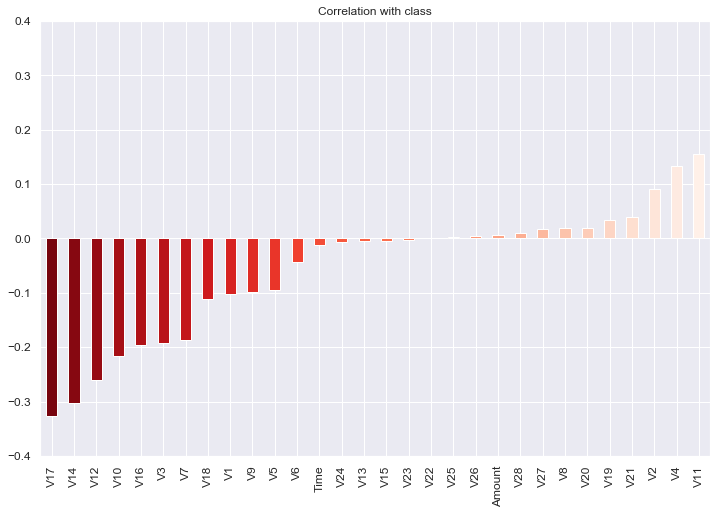

```python
target = 'Class'
df_corr = df.drop(target,1).corrwith(df[target]).sort_values()

df_corr.plot.bar(figsize = (12, 8), title = "Correlation with class",
          fontsize = 12,rot = 90, grid = True,
          color=sns.color_palette('Reds_r',30),ylim=(-0.4,0.4)
       )

# v17 14 12 and 10 has correlation more than 0.2
```

## Distribution plots

```python
df_corr.loc[ abs(df_corr.values)>0.2]
```

```
V17   -0.326481
V14   -0.302544
V12   -0.260593
V10   -0.216883
dtype: float64
```

```python
high_corr_idx = df_corr.loc[ abs(df_corr.values)>0.2].index.values.tolist()
high_corr_idx
```

```
['V17', 'V14', 'V12', 'V10']
```

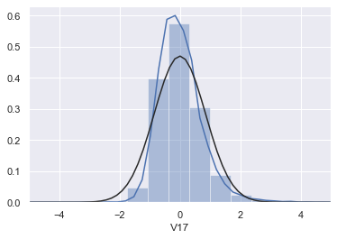

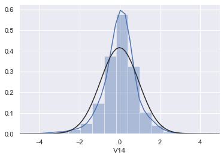

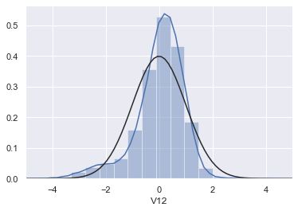

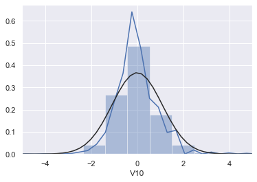

```python
def dist_plot():
    for c in high_corr_idx:
        sns.distplot(df[c],fit=scipy.stats.norm)
        plt.xlim(-5,5)
        plt.show()
        plt.close()

dist_plot()
```

```python
# clearly pdf is much different from gaussian distribution.
# to reduce skewness, we can we boxcox transform.
```

## Scaling

```python
# RobustScaler is less prone to outliers.
from sklearn.preprocessing import StandardScaler, RobustScaler

scaler = RobustScaler()

df['scaled_amount'] = scaler.fit_transform(df['Amount'].values.reshape(-1,1))
df['scaled_time'] = scaler.fit_transform(df['Time'].values.reshape(-1,1))
```

## Outliers Removal

[figure not shown]

```
Before removing outliers from highest correlated features:
```

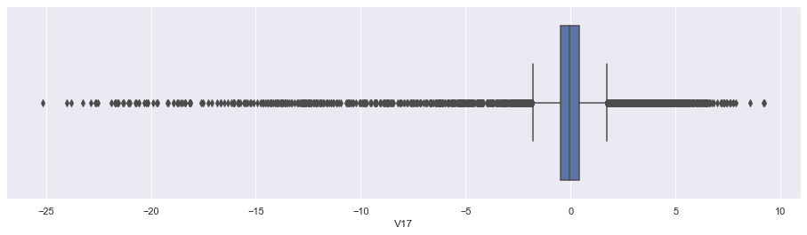

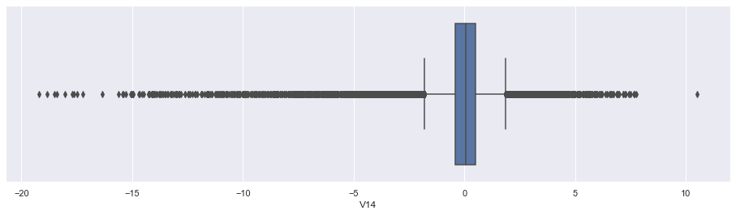

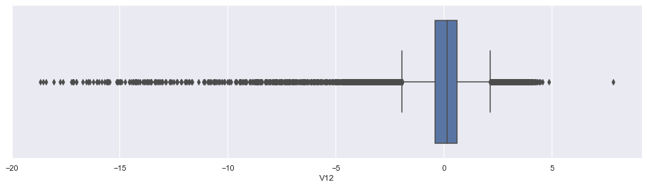

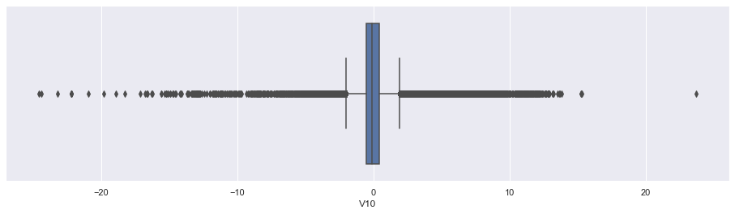

```python
def boxplots_with_outliers():
    print('Before removing outliers from highest correlated features:')
    for c in high_corr_idx:
        plt.figure(figsize=(16,4))
        sns.boxplot(df[c])
        plt.show()
        plt.close()

boxplots_with_outliers()
```

```python
# Find outliers using IQR method
q1 = df[high_corr_idx].quantile(0.25)
q3 = df[high_corr_idx].quantile(0.75)
iqr = q3 - q1
threshold = 1.5

cond1 = df[high_corr_idx] < (q1 - threshold * iqr)
cond2 = df[high_corr_idx] > (q3 + threshold * iqr)
cond = cond1 | cond2

idx_no_outliers = df[high_corr_idx][~(cond).any(axis=1)].index
idx_no_outliers[:5]
```

```
Int64Index([0, 1, 2, 3, 4], dtype='int64')
```

```python
df_no_outliers = df.loc[idx_no_outliers]
```

```python
df.shape, df_no_outliers.shape
```

```
((284807, 33), (250883, 33))
```

```
After removing outliers from highest correlated features:
```

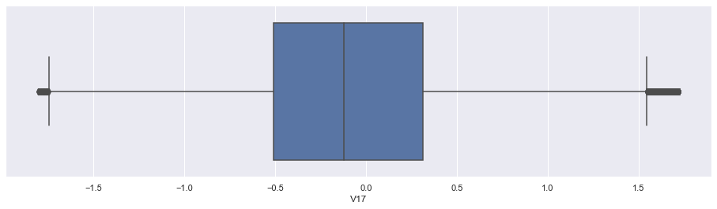

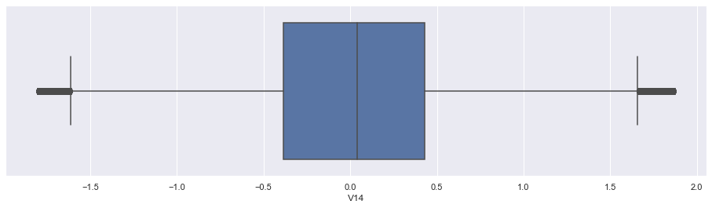

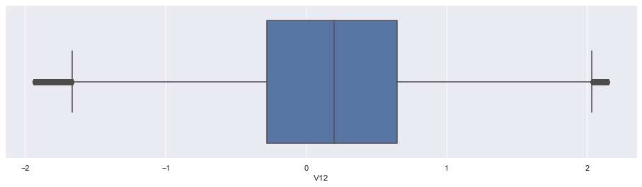

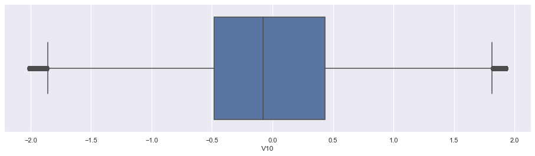

```python
def boxplots_no_outliers():
    print('After removing outliers from highest correlated features:')
    for c in high_corr_idx:
        plt.figure(figsize=(16,4))
        sns.boxplot(df_no_outliers[c])
        plt.show()
        plt.close()

boxplots_no_outliers()
```

## Random Under Sampling

- If classes are imbalanced, more frequent class causes overfitting.
- We can use undersampling of classes.
- Faster to train the model, since lower number of samples are remained.

Cons:

- Large number of rows may be dropped and risk of information loss.

```python
# without removing outliers
n = df[target].value_counts().values[-1]

df_under = (df.groupby(target)
                .apply(lambda x: x.sample(n,random_state=random_state))
                .reset_index(drop=True)
               )

df_under[target].value_counts()
```

```
1    492
0    492
Name: Class, dtype: int64
```

```python
df.shape, df_under.shape
# out of 284k samples, we now have 984 samples for undersampling
# we have lost 283k samples and have only 1k samples
# this is a lot of information losss, but still I will test the
# classifiers with this undersampling method.
#
# Later, I will use oversampling methods to do the modelling.
```

```
((284807, 33), (984, 33))
```

# Train Test split with stratify for imbalanced data

```python
df.columns
```

```
Index(['Time', 'V1', 'V2', 'V3', 'V4', 'V5', 'V6', 'V7', 'V8', 'V9', 'V10',
       'V11', 'V12', 'V13', 'V14', 'V15', 'V16', 'V17', 'V18', 'V19', 'V20',
       'V21', 'V22', 'V23', 'V24', 'V25', 'V26', 'V27', 'V28', 'Amount',
       'Class', 'scaled_amount', 'scaled_time'],
      dtype='object')
```

```python
(Xtrain_no_outliers, Xtest_no_outliers,
 ytrain_no_outliers, ytest_no_outliers) = \
    train_test_split(df_no_outliers.drop([target],1),
                     df_no_outliers[target],
                     random_state=random_state,
                     test_size=0.2,
                     stratify=df_no_outliers[target])

print(df.shape, Xtrain_no_outliers.shape, Xtest_no_outliers.shape)
columns = df_no_outliers.columns.difference([target]).values.tolist() + [target]

df_train_no_outliers = pd.DataFrame(data=np.c_[Xtrain_no_outliers,
                                               ytrain_no_outliers],
                                    columns=columns)

df_test_no_outliers = pd.DataFrame(data=np.c_[Xtest_no_outliers,
                                              ytest_no_outliers],
                                   columns=columns)

print(df.shape, df_train_no_outliers.shape, df_test_no_outliers.shape)
df_train_no_outliers.head(2)
```

```
(284807, 33) (200706, 32) (50177, 32)
(284807, 33) (200706, 33) (50177, 33)
```

|  | Amount | Time | V1 | V10 | V11 | V12 | V13 | V14 | V15 | V16 | V17 | V18 | V19 | V2 | V20 | V21 | V22 | V23 | V24 | V25 | V26 | V27 | V28 | V3 | V4 | V5 | V6 | V7 | V8 | … |
| --- | --- | --- | --- | --- | --- | --- | --- | --- | --- | --- | --- | --- | --- | --- | --- | --- | --- | --- | --- | --- | --- | --- | --- | --- | --- | --- | --- | --- | --- | --- |
| 0 | 153336.0 | 2.063767 | -0.488559 | -1.799317 | 0.518851 | 0.130354 | -0.503761 | 0.113631 | -0.224508 | -0.970983 | 1.241842 | -0.060205 | 0.170743 | -0.692233 | 0.700893 | -1.251801 | -1.867572 | -0.254898 | 1.432933 | -0.518657 | -0.657286 | -0.279769 | -0.254201 | -0.013790 | -0.608267 | 0.344953 | -0.476448 | -0.004394 | -0.067904 | … |
| 1 | 69329.0 | 1.237906 | 0.265153 | 0.180927 | 0.504037 | -0.193144 | -0.571533 | -0.055028 | -0.009820 | -0.136239 | -0.099655 | 1.261914 | 0.575181 | -0.252796 | -0.020983 | 0.466912 | 0.791755 | -0.349610 | 0.358501 | 0.218193 | -0.089781 | -0.263224 | -0.814410 | 0.082531 | -0.049334 | 0.214859 | 0.098921 | -0.030103 | 0.016190 | … |

```python
(Xtrain_under, Xtest_under,
 ytrain_under, ytest_under) = \
    train_test_split(df_under.drop([target],1),
                     df_under[target],
                     random_state=random_state,
                     test_size=0.2,
                     #stratify=df_under[target] # do no use stratify here.
                     )

print(df.shape, Xtrain_under.shape, Xtest_under.shape)
columns = df_no_outliers.columns.difference([target]).values.tolist() + [target]

df_train_under = pd.DataFrame(data=np.c_[Xtrain_under,
                                         ytrain_under],
                              columns=columns)

df_test_under = pd.DataFrame(data=np.c_[Xtest_under
                                        ,ytest_under],
                             columns=columns)

print(df.shape, df_train_under.shape, df_test_under.shape)
df_train_under.head(2)
```

```
(284807, 33) (787, 32) (197, 32)
(284807, 33) (787, 33) (197, 33)
```

|  | Amount | Time | V1 | V10 | V11 | V12 | V13 | V14 | V15 | V16 | V17 | V18 | V19 | V2 | V20 | V21 | V22 | V23 | V24 | V25 | V26 | V27 | V28 | V3 | V4 | V5 | V6 | V7 | V8 | … |
| --- | --- | --- | --- | --- | --- | --- | --- | --- | --- | --- | --- | --- | --- | --- | --- | --- | --- | --- | --- | --- | --- | --- | --- | --- | --- | --- | --- | --- | --- | --- |
| 0 | 147856.0 | 1.915851 | 0.665687 | -0.884928 | 3.489039 | 0.842344 | 0.315856 | 0.220146 | -0.016990 | -1.539009 | 1.678634 | 0.800689 | 0.763875 | 0.839985 | 0.430142 | -1.024695 | 1.021889 | -1.179907 | 0.101768 | -1.527063 | -0.210279 | 0.289098 | 0.828991 | 0.088947 | 0.716084 | 0.127340 | 0.079675 | -0.045138 | -0.054328 | … |
| 1 | 155662.0 | -1.928613 | 4.601506 | -7.124053 | 5.716088 | 1.026579 | -3.189073 | -2.261897 | 1.185096 | -4.441942 | -6.646154 | 3.827868 | -6.518649 | 0.251137 | -12.456706 | -0.649166 | -1.283145 | -2.718560 | -0.085466 | -2.097385 | 0.328796 | 0.602291 | -0.541287 | -0.354639 | -0.701492 | -0.030973 | 0.034070 | 0.573393 | 0.294686 | … |

```python
df_train_under['Class'].value_counts()
```

```
1.0    401
0.0    386
Name: Class, dtype: int64
```

```python
df_test_under['Class'].value_counts()
```

```
0.0    106
1.0     91
Name: Class, dtype: int64
```

## Check for nans before modelling

```python
for x in [df, df_under, df_no_outliers,
          df_train_under, df_test_under,
          df_train_no_outliers, df_test_no_outliers]:
    print(x.isnull().sum().sum())
```

```
0
0
0
0
0
0
0
```

```python
df_under.columns
```

```
Index(['Time', 'V1', 'V2', 'V3', 'V4', 'V5', 'V6', 'V7', 'V8', 'V9', 'V10',
       'V11', 'V12', 'V13', 'V14', 'V15', 'V16', 'V17', 'V18', 'V19', 'V20',
       'V21', 'V22', 'V23', 'V24', 'V25', 'V26', 'V27', 'V28', 'Amount',
       'Class', 'scaled_amount', 'scaled_time'],
      dtype='object')
```

```python
df_train_under.columns
```

```
Index(['Amount', 'Time', 'V1', 'V10', 'V11', 'V12', 'V13', 'V14', 'V15', 'V16',
       'V17', 'V18', 'V19', 'V2', 'V20', 'V21', 'V22', 'V23', 'V24', 'V25',
       'V26', 'V27', 'V28', 'V3', 'V4', 'V5', 'V6', 'V7', 'V8', 'V9',
       'scaled_amount', 'scaled_time', 'Class'],
      dtype='object')
```

# Modelling

**NOTE:** Confusion Matrix Terms  
Fraud ==> Fraud TP  
Non-Fraud ==> Non-Fraud TN  
Fraud ==> Non-Fraud FN (I am interested in this)  
Non-Fraud ==> Fraud FP

## Classifiers

```python
from sklearn.linear_model import LogisticRegression
from sklearn.svm import SVC
from sklearn.neighbors import KNeighborsClassifier
from sklearn.tree import DecisionTreeClassifier
from sklearn.ensemble import RandomForestClassifier
```

```python
features_with_log = df_under.columns.difference(
    ['Amount','Time','Class']).values.tolist()

features = features_with_log
print(features)
```

```
['V1', 'V10', 'V11', 'V12', 'V13', 'V14', 'V15', 'V16', 'V17', 'V18', 'V19', 'V2', 'V20', 'V21', 'V22', 'V23', 'V24', 'V25', 'V26', 'V27', 'V28', 'V3', 'V4', 'V5', 'V6', 'V7', 'V8', 'V9', 'scaled_amount', 'scaled_time']
```

```python
# numpy arrays
Xtrain = df_train_under[features].values
Xtest = df_test_under[features].values

ytrain = df_train_under[target].values.ravel()
ytest = df_test_under[target].values.ravel()

Xtrain.shape, ytrain.shape, Xtest.shape,  ytest.shape
```

```
((787, 30), (787,), (197, 30), (197,))
```

```python
clf_lr = LogisticRegression(solver='liblinear',
                            max_iter=4000,
                            random_state=random_state,
                            n_jobs=1,) # for liblinear n_jobs is +1.

clf_svc = SVC(random_state=random_state,gamma='scale')
clf_knn = KNeighborsClassifier(n_jobs=-1)
clf_dtc = DecisionTreeClassifier(random_state=random_state)
clf_rfc = RandomForestClassifier(n_estimators=100,
                                random_state=random_state,n_jobs=-1)

clf_names = ["Logisitic Regression","Support Vector Classifier",
            "KNN", "Decision Tree Classifier","Random Forest Classifier"]
```

## Recall Scores from Cross Validation

```python
X = df_under[features_with_log].values
y = df_under[target].values.ravel()
```

```python
from sklearn.model_selection import cross_val_score

classifiers = [clf_lr, clf_svc, clf_knn, clf_dtc, clf_rfc]
recall_cross_val_scores = []

t0 = time.time()
for clf in classifiers:
    clf.fit(X, y)
    score = cross_val_score(clf, X, y, cv=5,n_jobs=-1,scoring='recall')
    recall_cross_val_scores.append(score.mean())

t1 = (time.time() - t0)

print('Time taken: {} minutes {:.2f} seconds'.format(*divmod(t1,60)))

df_recall_cross_val_scores = pd.DataFrame({'Classifier': clf_names,
                'Recall Cross Validation Score': recall_cross_val_scores})

df_recall_cross_val_scores = df_recall_cross_val_scores\
    .sort_values('Recall Cross Validation Score',ascending=False)

df_recall_cross_val_scores.index = range(len(df_recall_cross_val_scores))

df_recall_cross_val_scores.style.background_gradient(
    subset=['Recall Cross Validation Score']).set_caption(
    'Recall Cross Validation Scores for Default Classifiers for Undersampled Data')
```

```
Time taken: 0.0 minutes 1.13 seconds
```

Recall Cross Validation Scores for Default Classifiers for Undersampled Data

|  | Classifier | Recall Cross Validation Score |
| --- | --- | --- |
| 0 | Logisitic Regression | 0.896269 |
| 1 | Random Forest Classifier | 0.896269 |
| 2 | Decision Tree Classifier | 0.894228 |
| 3 | KNN | 0.894207 |
| 4 | Support Vector Classifier | 0.871841 |

## ROC AUC Scores from Cross Validation

```python
from sklearn.model_selection import cross_val_predict
from sklearn.metrics import roc_auc_score



# logistic regression and svc have method decision function
cvpred_lr = cross_val_predict(clf_lr, X, y, cv=5,n_jobs=-1,
                             method="decision_function")
cvpred_svc = cross_val_predict(clf_svc, X, y, cv=5,n_jobs=-1,
                             method="decision_function")

# default cross val predict method is 'predict'
cvpred_knn = cross_val_predict(clf_knn, X, y, cv=5,n_jobs=-1)
cvpred_dtc = cross_val_predict(clf_dtc, X, y, cv=5,n_jobs=-1)
cvpred_rfc = cross_val_predict(clf_rfc, X, y, cv=5,n_jobs=-1)

all_cross_val_preds = [cvpred_lr, cvpred_svc, cvpred_knn, cvpred_dtc, cvpred_rfc]

all_roc_auc_scores = [roc_auc_score(y, cvpred)
                        for cvpred in all_cross_val_preds ]

# create dataframe of results
col = 'Cross Validation AUROC Scores'
df_cross_val_preds = pd.DataFrame({'Classifier': clf_names,
                                   col: all_roc_auc_scores})


df_cross_val_preds = df_cross_val_preds.sort_values(col,ascending=False)
df_cross_val_preds.index = range(len(df_cross_val_preds))

title = 'Cross Validation AUROC Scores for Default Classifiers '
title += 'for Undersampled Data'
df_cross_val_preds.style.background_gradient(subset=[col])\
    .set_caption(title)
```

Cross Validation AUROC Scores for Default Classifiers for Undersampled Data

|  | Classifier | Cross Validation AUROC Scores |
| --- | --- | --- |
| 0 | Support Vector Classifier | 0.979885 |
| 1 | Logisitic Regression | 0.975118 |
| 2 | Random Forest Classifier | 0.930894 |
| 3 | KNN | 0.930894 |
| 4 | Decision Tree Classifier | 0.889228 |

## Grid Search and Randomized Search

```python
from sklearn.model_selection import GridSearchCV, RandomizedSearchCV
```

```python
def get_best_estimator(clf, params,Xtrain,ytrain,fname=None,
                       random_state=100,
                       verbose=1,
                       use_gridcv=True,
                       scoring='recall'):
    """Find the best estimator using grid search.

    GridSearchCV does not have random_state, it goes through all the
    parameters given to it. It is slow but guarenteed to give best among them.

    RandomizedSearchCV do have random_state. It is fast
    but is not guarenteed to give the best set of params among them.

    """
    import time
    from sklearn.model_selection import GridSearchCV, RandomizedSearchCV

    t0 = time.time()

    if use_gridcv:
        # GridSearchCV does not have random_state and n_iter
        print('Please wait .. doing grid search cv')
        grid = GridSearchCV(clf, params,cv=5,n_jobs=-1,
                              verbose=verbose,scoring=scoring)
    else:
        print('Please wait .. doing randomized search cv')
        grid = RandomizedSearchCV(clf, params,cv=5,n_jobs=-1,n_iter=10,
                              verbose=verbose,scoring=scoring,
                              random_state=random_state)

    grid.fit(Xtrain, ytrain)

    clf_best = grid.best_estimator_

    if fname:
        joblib.dump(clf_best, fname)

    t1 = time.time() - t0
    print('Time taken: {:.0f} min {:.0f} secs'.format(*divmod(t1,60)))

    return clf_best
```

```python
# Logistic Regression
# liblinear supports penalty l1 and l2, but lbfgs support only l2.
# generally we choose C in log scale.
params_lr = {"penalty": ['l1', 'l2'],
                  'C': [0.001, 0.01, 0.1, 1, 10, 100, 1000]}


fname = '../models/serialization/clf_best_lr.pkl'
# clf_best_lr = get_best_estimator(clf_lr, params_lr,Xtrain,ytrain,fname)

# After getting the best classifier, comment the code.

# Time taken:  3 min 28 secs for gridsearch
```

```python
fname = '../models/serialization/clf_best_lr.pkl'
clf_best_lr = joblib.load(fname)

clf_best_lr
```

```
LogisticRegression(C=0.001, class_weight=None, dual=False, fit_intercept=True,
                   intercept_scaling=1, l1_ratio=None, max_iter=4000,
                   multi_class='warn', n_jobs=1, penalty='l1', random_state=100,
                   solver='liblinear', tol=0.0001, verbose=0, warm_start=False)
```

```python
# Support Vector Classifier
params_svc = {'C': [0.5, 0.7, 0.9, 1],
              'kernel': ['rbf', 'poly', 'sigmoid', 'linear']}

fname = '../models/serialization/clf_best_svc.pkl'
# clf_best_svc = get_best_estimator(clf_svc,params_svc,Xtrain,ytrain,fname)

# Time taken: Time taken: 1 min 4 secs
```

```python
fname = '../models/serialization/clf_best_svc.pkl'
clf_best_svc = joblib.load(fname)
```

```python
# K-nearest neighbor
params_knn = {"n_neighbors": list(range(2,5,1)),
              'algorithm': ['auto', 'ball_tree', 'kd_tree', 'brute']}

fname = '../models/serialization/clf_best_knn.pkl'
clf_best_knn = get_best_estimator(clf_knn, params_knn,Xtrain,ytrain,fname)

# Time taken: 0 min 3 secs
```

```
Please wait .. doing grid search cv
Fitting 5 folds for each of 12 candidates, totalling 60 fits
```

```
[Parallel(n_jobs=-1)]: Using backend LokyBackend with 4 concurrent workers.
```

```
Time taken: 0 min 2 secs
```

```
[Parallel(n_jobs=-1)]: Done  60 out of  60 | elapsed:    1.8s finished
```

```python
# DecisionTree Classifier
params_dtc = {"criterion": ["gini", "entropy"],
               "max_depth": list(range(2,4,1)),
              "min_samples_leaf": list(range(5,7,1))}

fname = '../models/serialization/clf_best_dtree.pkl'
clf_best_dtc = get_best_estimator(clf_dtc, params_dtc,Xtrain,ytrain,fname)

# Time taken: 0 min 2 secs
```

```
[Parallel(n_jobs=-1)]: Using backend LokyBackend with 4 concurrent workers.
```

```
Please wait .. doing grid search cv
Fitting 5 folds for each of 8 candidates, totalling 40 fits
Time taken: 0 min 0 secs
```

```
[Parallel(n_jobs=-1)]: Done  40 out of  40 | elapsed:    0.2s finished
```

```python
# Random Forest Classifier

clf_rfc = RandomForestClassifier(random_state=random_state)

n_estimators = [200,500,1000,1500,2000]
max_depth = [10,20,40,80,100,120]

max_features = ['auto', 'sqrt']
bootstrap = [True, False]

min_samples_split = [2, 5, 10]
min_samples_leaf = [1, 2, 4]

params_rfc = {'n_estimators': n_estimators,
               'max_features': max_features,
               'max_depth': max_depth,
               'min_samples_split': min_samples_split,
               'min_samples_leaf': min_samples_leaf,
               'bootstrap': bootstrap}

fname = '../models/serialization/clf_best_rfc.pkl'
clf_best_rfc = get_best_estimator(clf_rfc, params_rfc,Xtrain,ytrain,fname,
                                 use_gridcv=False)

# Time taken: 0 min 48 secs
```

```
Please wait .. doing randomized search cv
Fitting 5 folds for each of 10 candidates, totalling 50 fits
```

```
[Parallel(n_jobs=-1)]: Using backend LokyBackend with 4 concurrent workers.
[Parallel(n_jobs=-1)]: Done  42 tasks      | elapsed:   34.6s
[Parallel(n_jobs=-1)]: Done  50 out of  50 | elapsed:   37.6s finished
```

```
Time taken: 0 min 43 secs
```

```python
fname = '../models/serialization/clf_best_rfc.pkl'
clf_best_rfc = joblib.load(fname)
```

# Model Evaluation

[figure not shown]

## Get Predictions

```python
ypreds_lr = clf_lr.predict(Xtest)
ypreds_svc = clf_svc.predict(Xtest)
ypreds_knn = clf_knn.predict(Xtest)
ypreds_dtc = clf_dtc.predict(Xtest)
ypreds_rfc = clf_rfc.predict(Xtest)
```

```python
df_false_negatives = get_false_negative_frauds('Logistic Regression',
   ytest,ypreds_lr,
   desc="Undersample",
   df_false_negatives=None,
   show=False);

df_false_negatives = get_false_negative_frauds('Support Vector Classifier',
   ytest,ypreds_svc,
   desc="Undersample",
   df_false_negatives=df_false_negatives,
   show=False);

df_false_negatives = get_false_negative_frauds('KNN',
   ytest,ypreds_knn,
   desc="Undersample",
   df_false_negatives=df_false_negatives,
   show=False);

df_false_negatives = get_false_negative_frauds('Decision Tree Classifier',
   ytest,ypreds_dtc,
   desc="Undersample",
   df_false_negatives=df_false_negatives,
   show=False);

df_false_negatives = get_false_negative_frauds('Random Forest Classifier',
   ytest,ypreds_rfc,
   desc="Undersample",
   df_false_negatives=df_false_negatives,
   show=True);
```

|  | Model | Description | Total_Frauds | Incorrect_Frauds | Incorrect_Percent |
| --- | --- | --- | --- | --- | --- |
| 0 | Support Vector Classifier | Undersample | 91 | 12 | 13.19 % |
| 1 | Random Forest Classifier | Undersample | 91 | 17 | 18.68 % |
| 2 | Decision Tree Classifier | Undersample | 91 | 19 | 20.88 % |
| 3 | Logistic Regression | Undersample | 91 | 39 | 42.86 % |
| 4 | KNN | Undersample | 91 | 61 | 67.03 % |

```python
ypreds_best_lr = clf_best_lr.predict(Xtest)
ypreds_best_svc = clf_best_svc.predict(Xtest)
ypreds_best_knn = clf_best_knn.predict(Xtest)
ypreds_best_dtc = clf_best_dtc.predict(Xtest)
ypreds_best_rfc = clf_best_rfc.predict(Xtest)
```

## Scalar Classification Metrics

```python
from sklearn.metrics import accuracy_score
from sklearn.metrics import precision_score
from sklearn.metrics import recall_score
from sklearn.metrics import f1_score

from bhishan.util_model_eval import get_binary_classification_scalar_metrics
```

```python
df_eval = get_binary_classification_scalar_metrics(
    "Logistic Regression",
    clf_best_lr,
    Xtest,ytest,
    ypreds_best_lr,
    desc="Undersample, Grid Search", df_eval=None,show=False)

df_eval = get_binary_classification_scalar_metrics(
    'Support Vector Classifier',
    clf_best_svc,
    Xtest,ytest,
    ypreds_best_lr,
    desc="Undersample, Grid Search", df_eval=df_eval,show=False)

df_eval = get_binary_classification_scalar_metrics(
    'KNN',
    clf_best_knn,
    Xtest,ytest,
    ypreds_best_knn,
    desc="Undersample, Grid Search", df_eval=df_eval,show=False)

df_eval = get_binary_classification_scalar_metrics(
    'Decision Tree Classifier',
    clf_best_dtc,
    Xtest,ytest,
    ypreds_best_dtc,
    desc="Undersample, Grid Search", df_eval=df_eval,show=False)

df_eval = get_binary_classification_scalar_metrics(
    'Random Forest Classifier',
    clf_best_rfc,
    Xtest,ytest,
    ypreds_best_rfc,
    desc="Undersample, Grid Search", df_eval=df_eval)
```

|  | Model | Description | Accuracy | Precision | Recall | F1 | Mathews Correlation Coefficient | Cohens Kappa | Area Under Precision Curve | Area Under ROC Curve |
| --- | --- | --- | --- | --- | --- | --- | --- | --- | --- | --- |
| 0 | Logistic Regression | Undersample, Grid Search | 0.741117 | 0.651515 | 0.945055 | 0.7713 | 0.541913 | 0.495303 | 0.95003 | 0.931474 |
| 1 | Support Vector Classifier | Undersample, Grid Search | 0.741117 | 0.651515 | 0.945055 | 0.7713 | 0.541913 | 0.495303 | 0.962546 | 0.94464 |
| 2 | Random Forest Classifier | Undersample, Grid Search | 0.913706 | 0.95122 | 0.857143 | 0.901734 | 0.828738 | 0.825181 | 0.981182 | 0.977918 |
| 3 | KNN | Undersample, Grid Search | 0.888325 | 0.915663 | 0.835165 | 0.873563 | 0.776569 | 0.773941 | 0.903222 | 0.93163 |
| 4 | Decision Tree Classifier | Undersample, Grid Search | 0.898477 | 0.949367 | 0.824176 | 0.882353 | 0.79999 | 0.793847 | 0.903238 | 0.931371 |

```python
from sklearn.metrics import accuracy_score, precision_score, recall_score, f1_score

print('Accuracy: ', accuracy_score(ytest,ypreds_best_lr))
print('Precision: ', precision_score(ytest,ypreds_best_lr))
print('Recall: ', recall_score(ytest,ypreds_best_lr))
print('F1-score: ', f1_score(ytest,ypreds_best_lr))
```

```
Accuracy:  0.7411167512690355
Precision:  0.6515151515151515
Recall:  0.945054945054945
F1-score:  0.7713004484304932
```

## Classification Report

```python
from sklearn.metrics import classification_report
from bhishan.util_model_eval import get_binary_classification_report
```

```python
df_clf_report = get_binary_classification_report("Logistic Regression",
  ytest,
  ypreds_best_lr,
  desc='Undersample, Grid Search',
  style_col='Recall_1',
  df_clf_report=None,show=False)

df_clf_report = get_binary_classification_report("Support Vector Classifier",
  ytest,
  ypreds_best_svc,
  desc='Undersample, Grid Search',
  style_col='Recall_1',
  df_clf_report=df_clf_report,show=False)

df_clf_report = get_binary_classification_report("KNN",
  ytest,
  ypreds_best_knn,
  desc='Undersample, Grid Search',
  style_col='Recall_1',
  df_clf_report=df_clf_report,show=False)

df_clf_report = get_binary_classification_report("Decision Tree Classifier",
  ytest,
  ypreds_best_dtc,
  desc='Undersample, Grid Search',
  style_col='Recall_1',
  df_clf_report=df_clf_report,show=False)

df_clf_report = get_binary_classification_report("Random Forest Classifier",
  ytest,
  ypreds_best_rfc,
  desc='Undersample, Grid Search',
  style_col='Recall_1',
  df_clf_report=df_clf_report,show=True)
```

|  | Model | Desc | Precision_0 | Precision_1 | Recall_0 | Recall_1 | F1_Score_0 | F1_Score_1 | Support_0 | Support_1 |
| --- | --- | --- | --- | --- | --- | --- | --- | --- | --- | --- |
| 0 | Logistic Regression | Undersample, Grid Search | 0.923077 | 0.651515 | 0.566038 | 0.945055 | 0.701754 | 0.7713 | 106 | 91 |
| 1 | Support Vector Classifier | Undersample, Grid Search | 0.901786 | 0.941176 | 0.95283 | 0.879121 | 0.926606 | 0.909091 | 106 | 91 |
| 4 | Random Forest Classifier | Undersample, Grid Search | 0.886957 | 0.95122 | 0.962264 | 0.857143 | 0.923077 | 0.901734 | 106 | 91 |
| 2 | KNN | Undersample, Grid Search | 0.868421 | 0.915663 | 0.933962 | 0.835165 | 0.9 | 0.873563 | 106 | 91 |
| 3 | Decision Tree Classifier | Undersample, Grid Search | 0.864407 | 0.949367 | 0.962264 | 0.824176 | 0.910714 | 0.882353 | 106 | 91 |

```python
print(classification_report(ytest, ypreds_best_lr))
```

```
              precision    recall  f1-score   support

         0.0       0.92      0.57      0.70       106
         1.0       0.65      0.95      0.77        91

    accuracy                           0.74       197
   macro avg       0.79      0.76      0.74       197
weighted avg       0.80      0.74      0.73       197
```

## Confusion Matrix

```python
from sklearn.metrics import confusion_matrix
from bhishan.util_model_eval import print_confusion_matrix_frauds
from bhishan.util_model_eval import plot_confusion_matrix_plotly
```

```python
print_confusion_matrix_frauds(
    "Logistic Regression, Undersample, Grid Search",
    ytest,ypreds_best_lr)
```

Logistic Regression, Undersample, Grid Search

|  | Predicted_No_Fraud | Predicted_Fraud | Total_Frauds | Correct_Frauds | Incorrect_Frauds | Fraud_Detection |
| --- | --- | --- | --- | --- | --- | --- |
| No_Fraud | 60 | 46 | 91 | 86 | 5 | 94.51% |
| Fraud | 5 | 86 | 91 | 86 | 5 | 94.51% |

```python
print_confusion_matrix_frauds(
    "Random Forest Classifier, Undersample, Grid Search",
    ytest,ypreds_best_rfc)
```

Random Forest Classifier, Undersample, Grid Search

|  | Predicted_No_Fraud | Predicted_Fraud | Total_Frauds | Correct_Frauds | Incorrect_Frauds | Fraud_Detection |
| --- | --- | --- | --- | --- | --- | --- |
| No_Fraud | 102 | 4 | 91 | 78 | 13 | 85.71% |
| Fraud | 13 | 78 | 91 | 78 | 13 | 85.71% |

```python
plot_confusion_matrix_plotly(ytest, ypreds_best_lr)
```

[interactive chart not shown]

```python
confusion_matrix(ytest, ypreds_best_lr)
```

```
array([[60, 46],
       [ 5, 86]])
```

## False Negative Counts

```python
# help(confusion_matrix)
```

```python
tn, fp, fn, tp = confusion_matrix(ytest, ypreds_best_lr).ravel()
tn, fp, fn, tp
```

```
(60, 46, 5, 86)
```

```python
df_ytest_ypreds = pd.DataFrame({'ytest': ytest,
                               'ypreds': ypreds_best_lr})

df_ytest_ypreds.head()
```

|  | ytest | ypreds |
| --- | --- | --- |
| 0 | 1.0 | 0.0 |
| 1 | 1.0 | 1.0 |
| 2 | 0.0 | 0.0 |
| 3 | 1.0 | 1.0 |
| 4 | 1.0 | 1.0 |

```python
df_ytest_ypreds.query("ytest == 1.0 and ypreds == 0.0")
```

|  | ytest | ypreds |
| --- | --- | --- |
| 0 | 1.0 | 0.0 |
| 28 | 1.0 | 0.0 |
| 76 | 1.0 | 0.0 |
| 166 | 1.0 | 0.0 |
| 185 | 1.0 | 0.0 |

```python
df_ytest_ypreds.query("ytest == 1.0 and ypreds == 0.0").shape
```

```
(5, 2)
```

```python
from bhishan.util_model_eval import get_false_negative_frauds
```

```python
df_false_negatives = get_false_negative_frauds('Logistic Regression',
   ytest,ypreds_best_lr,
   desc="Undersample, grid search",
   df_false_negatives=None,
   show=False);

df_false_negatives = get_false_negative_frauds('Support Vector Classifier',
   ytest,ypreds_best_svc,
   desc="Undersample, grid search",
   df_false_negatives=df_false_negatives,
   show=False);

df_false_negatives = get_false_negative_frauds('KNN',
   ytest,ypreds_best_knn,
   desc="Undersample, grid search",
   df_false_negatives=df_false_negatives,
   show=False);

df_false_negatives = get_false_negative_frauds('Decision Tree Classifier',
   ytest,ypreds_best_dtc,
   desc="Undersample, grid search",
   df_false_negatives=df_false_negatives,
   show=False);

df_false_negatives = get_false_negative_frauds('Random Forest Classifier',
   ytest,ypreds_best_rfc,
   desc="Undersample, grid search",
   df_false_negatives=df_false_negatives,
   show=True);
```

|  | Model | Description | Total_Frauds | Incorrect_Frauds | Incorrect_Percent |
| --- | --- | --- | --- | --- | --- |
| 0 | Logistic Regression | Undersample, grid search | 91 | 5 | 5.49 % |
| 1 | Support Vector Classifier | Undersample, grid search | 91 | 11 | 12.09 % |
| 2 | Random Forest Classifier | Undersample, grid search | 91 | 13 | 14.29 % |
| 3 | KNN | Undersample, grid search | 91 | 15 | 16.48 % |
| 4 | Decision Tree Classifier | Undersample, grid search | 91 | 16 | 17.58 % |

## ROC Curve

```python
from bhishan.util_model_eval import plot_roc_skf
```

```python
clf_best_lr
```

```
LogisticRegression(C=0.001, class_weight=None, dual=False, fit_intercept=True,
                   intercept_scaling=1, l1_ratio=None, max_iter=4000,
                   multi_class='warn', n_jobs=1, penalty='l1', random_state=100,
                   solver='liblinear', tol=0.0001, verbose=0, warm_start=False)
```

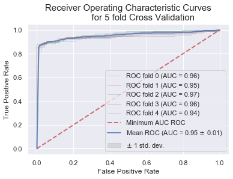

```python
X = df_under[features_with_log].values
y = df_under[target].values

clf_lr = LogisticRegression(C=0.001, class_weight=None, dual=False,
                   fit_intercept=True,
                   intercept_scaling=1, l1_ratio=None, max_iter=4000,
                   multi_class='warn', n_jobs=1, penalty='l1',
                   random_state=100,
                   solver='liblinear', tol=0.0001, verbose=0,
                   warm_start=False)


ofile = '../reports/figures/cv_auroc_lr_undersample_grid.png'
plot_roc_skf(clf_lr, X,y,random_state=random_state,ofile=ofile)
```

```python
from sklearn.model_selection import cross_val_predict
from sklearn.metrics import roc_auc_score
from sklearn.metrics import roc_curve
```

```python
def plot_roc_curve(clf_names, all_roc_auc_scores, y,ofile=None):
    """Plot Receiver Operating Characteristic (ROC) curve.

    NOTE:
    In cross-validation we do not need Xtrain and Xtest,
    one split of X is taken as Xtest and remaining splits are taken as Xtrain.

    Example:
    ---------
    clf_names = ["Logisitic Regression","Support Vector Classifier",
                 "KNN", "Decision Tree Classifier","Random Forest Classifier"]

    cvpred_lr = cross_val_predict(clf_best_lr, X, y, cv=5,
                             method="decision_function")
    cvpred_svc = cross_val_predict(clf_best_svc, X, y, cv=5,
                                 method="decision_function")

    cvpred_knn = cross_val_predict(clf_best_knn,X,y,cv=5)
    cvpred_dtc = cross_val_predict(clf_best_dtc,X,y,cv=5)
    cvpred_rfc = cross_val_predict(clf_best_rfc, X, y, cv=5)

    all_cross_val_preds = [cvpred_lr, cvpred_svc,
                             cvpred_knn, cvpred_dtc, cvpred_rfc]

    all_roc_auc_scores = [roc_auc_score(y, cvpred)
                        for cvpred in all_cross_val_preds ]

    plot_roc_curve(clf_names, all_roc_auc_scores,y)

    """
    from sklearn.model_selection import cross_val_predict
    from sklearn.metrics import roc_auc_score
    from sklearn.metrics import roc_curve

    labels = ['{}: {:.4f}'.format(clf,pred)
              for clf,pred in zip(clf_names,all_roc_auc_scores)]

    fpr_tpr_threshold = [ roc_curve(y, pred_x)
                         for pred_x in all_cross_val_preds ]

    plt.figure(figsize=(12,8))
    for i in range(len(fpr_tpr_threshold)):
        plt.plot(fpr_tpr_threshold[i][0],
                 fpr_tpr_threshold[i][1],
                 label=labels[i])

    plt.plot([0, 1], [0, 1], 'k--')
    plt.axis([-0.01, 1, 0, 1])
    plt.xlabel('False Positive Rate (FPR)', fontsize=16)
    plt.ylabel('True Positive Rate (TPR)', fontsize=16)
    plt.annotate('Minimum ROC Score of 50%',
                 xy=(0.5, 0.5), xytext=(0.6, 0.3),
                arrowprops=dict(facecolor='#6E726D', shrink=0.05),
                )
    plt.title('ROC Curves',fontsize=20)
    plt.legend()
    plt.tight_layout()

    # save the figure
    if ofile:
        plt.savefig(ofile,dpi=300)

    # show the figure
    plt.show()
    plt.close()
```

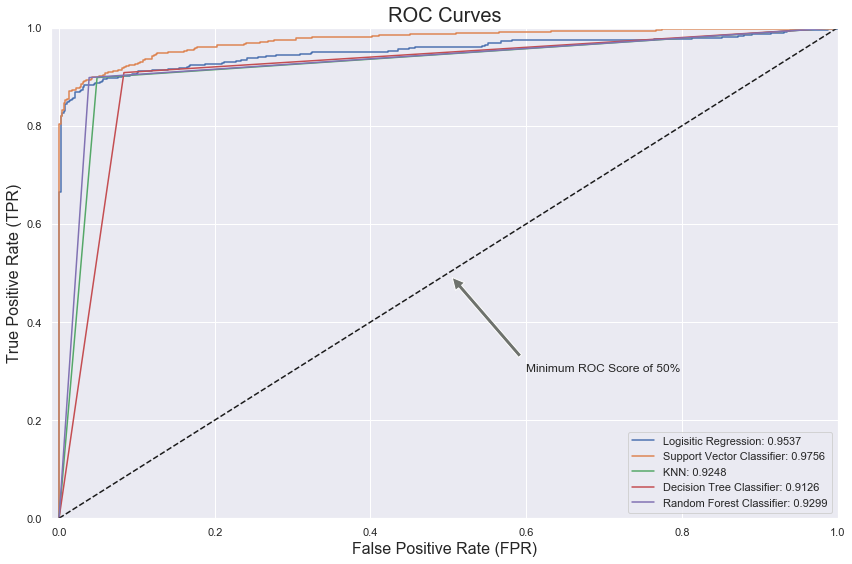

```
Time taken: 0 min 24 secs
```

```python
t0 = time.time()

clf_names = ["Logisitic Regression","Support Vector Classifier",
             "KNN", "Decision Tree Classifier","Random Forest Classifier"]

cvpred_lr = cross_val_predict(clf_best_lr, X, y, cv=5,
                         method="decision_function")
cvpred_svc = cross_val_predict(clf_best_svc, X, y, cv=5,
                             method="decision_function")

cvpred_knn = cross_val_predict(clf_best_knn,X,y,cv=5)
cvpred_dtc = cross_val_predict(clf_best_dtc,X,y,cv=5)
cvpred_rfc = cross_val_predict(clf_best_rfc, X, y, cv=5)

all_cross_val_preds = [cvpred_lr, cvpred_svc,
                         cvpred_knn, cvpred_dtc, cvpred_rfc]

all_roc_auc_scores = [roc_auc_score(y, cvpred)
                    for cvpred in all_cross_val_preds ]

ofile = '../reports/figures/roc_curves_for_all_clf.png'
plot_roc_curve(clf_names, all_roc_auc_scores,y,ofile=ofile)

t1 = time.time() - t0
print('Time taken: {:.0f} min {:.0f} secs'.format(*divmod(t1,60)))
# Time taken: 0 min 24 secs
```

## Plotly Model Evaluation Plots

```python
import plotly
plotly.__version__
```

```
'3.10.0'
```

```python
from bhishan.util_plot_model_eval import plotly_binary_clf_evaluation

yscore_best_lr = clf_best_lr.decision_function(Xtest)

ofile = '../reports/html/logistic_regression_model_evaluation.html'
plotly_binary_clf_evaluation('clf_best_lr',clf_best_lr,ytest,
                             ypreds_best_lr,yscore_best_lr,
                             df_under,ofile=ofile,show=False)

plotly_binary_clf_evaluation('clf_best_lr',clf_best_lr,ytest,
                             ypreds_best_lr,yscore_best_lr,
                             df_under[features_with_log],show=True)
```

[interactive chart not shown]

## Feature Importances from Random Forest Classifier

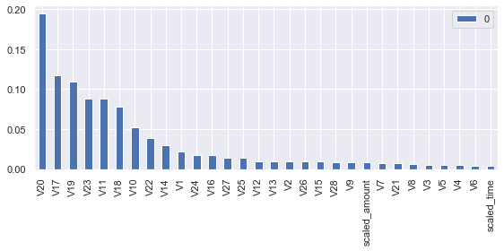

```python
features = df.columns.difference(['Amount','Time','Class']).values

fname = '../models/serialization/clf_best_rfc.pkl'
clf_best_rfc = joblib.load(fname)

df_imp = pd.DataFrame(data=clf_best_rfc.feature_importances_,
             index=features).sort_values(by=0,ascending=False)


df_imp.plot.bar(figsize=(8,4))
plt.tight_layout()
plt.savefig('../reports/clf_best_rfc_feature_importances.png', dpi=300)
```